# chicago_bikeshare_pt

### Projeto - chicago_bikeshare_pt

Originalmente o **PROJETO 1** do Nanodegree Data Science I não foi desenvolvido com o Jupyter, e sim utilizando o PyCharm para elaborar o script e rodar no termianl, aqui estarei refazendo o projeto utilizando o Jupyter Notebook e Pandas.

Do projeto: explorando dados relacionados aos sistemas de compartilhamento de bicicletas nas três maiores cidades dos Estados Unidos: Chicago, Nova Iorque e Washington.

[figure not shown]

O **Divvy** é um sistema de compartilhamento de bicicletas da cidade de Chicago e dois subúrbios adjacentes (imagem: [Wikipédia](https://en.wikipedia.org/wiki/Divvy))

```python
# Importando as biblioteca
import pandas as pd
import matplotlib.pyplot as plt
from datetime import datetime

%matplotlib inline
```

```python
# Carregando os dados

df_bike = pd.read_csv('chicago.csv')
df_bike.head()
```

|  | Start Time | End Time | Trip Duration | Start Station | End Station | User Type | Gender | Birth Year |
| --- | --- | --- | --- | --- | --- | --- | --- | --- |
| 0 | 2017-01-01 00:00:36 | 2017-01-01 00:06:32 | 356 | Canal St & Taylor St | Canal St & Monroe St (*) | Customer | NaN | NaN |
| 1 | 2017-01-01 00:02:54 | 2017-01-01 00:08:21 | 327 | Larrabee St & Menomonee St | Sheffield Ave & Kingsbury St | Subscriber | Male | 1984.0 |
| 2 | 2017-01-01 00:06:06 | 2017-01-01 00:18:31 | 745 | Orleans St & Chestnut St (NEXT Apts) | Ashland Ave & Blackhawk St | Subscriber | Male | 1985.0 |
| 3 | 2017-01-01 00:07:28 | 2017-01-01 00:12:51 | 323 | Franklin St & Monroe St | Clinton St & Tilden St | Subscriber | Male | 1990.0 |
| 4 | 2017-01-01 00:07:57 | 2017-01-01 00:20:53 | 776 | Broadway & Barry Ave | Sedgwick St & North Ave | Subscriber | Male | 1990.0 |

### Colunas do nosso dataframe:

```
 - Trip start day and time
 - Trip end day and time
 - Trip start station
 - Trip end station
 - User Type - Member, Single Ride, and Explore Pass
 - If a Member trip, it will also include Member’s gender and year of birth
```

### Tarefas do Projeto 1 - realizado apenas em python

```
- Tarefa 1: Mostre as 20 primeiras amostras (linhas) da base de dados
- Tarefa 2: Mostre o gênero (coluna) das 20 primeiras amostras
- Tarefa 3: Cria uma função para pegar colunas como lista
- Tarefa 4: Conte quantas pessoas de cada gênero
- Tarefa 5: Crie uma função para contar os gêneros
- Tarefa 6: Mostre o gênero mais popular
- Tarefa 7: Mostre um gráfico usando os dados anteriores
- Tarefa 8: Responda o motivo do número de homens e mulheres não bater com a quantidade de amostras
- Tarefa 9: Encontre o valor mínimo, máximo, média e mediana da duração de viagens
- Tarefa 10: Mostre todas as estações da base de dados
- Tarefa 11: Confira se documentou todas suas funções
- Tarefa 12: Crie uma função que conte a ocorrência de qualquer coluna (opcional)
```

```python
# Tarefa 1: Mostre as 20 primeiras amostras (linhas) da base de dados
df_bike.head(20)
```

|  | Start Time | End Time | Trip Duration | Start Station | End Station | User Type | Gender | Birth Year |
| --- | --- | --- | --- | --- | --- | --- | --- | --- |
| 0 | 2017-01-01 00:00:36 | 2017-01-01 00:06:32 | 356 | Canal St & Taylor St | Canal St & Monroe St (*) | Customer | NaN | NaN |
| 1 | 2017-01-01 00:02:54 | 2017-01-01 00:08:21 | 327 | Larrabee St & Menomonee St | Sheffield Ave & Kingsbury St | Subscriber | Male | 1984.0 |
| 2 | 2017-01-01 00:06:06 | 2017-01-01 00:18:31 | 745 | Orleans St & Chestnut St (NEXT Apts) | Ashland Ave & Blackhawk St | Subscriber | Male | 1985.0 |
| 3 | 2017-01-01 00:07:28 | 2017-01-01 00:12:51 | 323 | Franklin St & Monroe St | Clinton St & Tilden St | Subscriber | Male | 1990.0 |
| 4 | 2017-01-01 00:07:57 | 2017-01-01 00:20:53 | 776 | Broadway & Barry Ave | Sedgwick St & North Ave | Subscriber | Male | 1990.0 |
| 5 | 2017-01-01 00:10:44 | 2017-01-01 00:21:27 | 643 | State St & Kinzie St | Wells St & Polk St | Subscriber | Male | 1970.0 |
| 6 | 2017-01-01 00:11:34 | 2017-01-01 00:23:47 | 733 | Wabash Ave & Wacker Pl | Clinton St & Tilden St | Subscriber | Male | 1986.0 |
| 7 | 2017-01-01 00:14:57 | 2017-01-01 00:26:22 | 685 | Daley Center Plaza | Canal St & Monroe St (*) | Customer | NaN | NaN |
| 8 | 2017-01-01 00:15:03 | 2017-01-01 00:26:28 | 685 | Daley Center Plaza | Canal St & Monroe St (*) | Customer | NaN | NaN |
| 9 | 2017-01-01 00:17:01 | 2017-01-01 00:29:49 | 768 | Dayton St & North Ave | Ogden Ave & Chicago Ave | Customer | NaN | NaN |
| 10 | 2017-01-01 00:17:13 | 2017-01-01 11:03:34 | 38781 | Wilton Ave & Diversey Pkwy | Halsted St & Wrightwood Ave | Subscriber | Female | 1988.0 |
| 11 | 2017-01-01 00:18:28 | 2017-01-01 00:31:05 | 757 | Canal St & Madison St | LaSalle St & Illinois St | Customer | NaN | NaN |
| 12 | 2017-01-01 00:18:50 | 2017-01-01 00:21:47 | 177 | Theater on the Lake | Lakeview Ave & Fullerton Pkwy | Subscriber | Male | 1991.0 |
| 13 | 2017-01-01 00:23:41 | 2017-01-01 00:29:13 | 332 | Halsted St & Maxwell St | Halsted St & 18th St | Subscriber | Male | 1984.0 |
| 14 | 2017-01-01 00:25:47 | 2017-01-01 00:39:53 | 846 | Ravenswood Ave & Lawrence Ave | Clarendon Ave & Gordon Ter | Subscriber | Female | 1987.0 |
| 15 | 2017-01-01 00:25:47 | 2017-01-01 00:43:23 | 1056 | Clark St & Congress Pkwy | Wolcott Ave & Polk St | Subscriber | Male | 1984.0 |
| 16 | 2017-01-01 00:26:21 | 2017-01-01 00:39:40 | 799 | Ravenswood Ave & Lawrence Ave | Clarendon Ave & Gordon Ter | Subscriber | Male | 1987.0 |
| 17 | 2017-01-01 00:27:21 | 2017-01-01 00:42:59 | 938 | Millennium Park | Michigan Ave & 18th St | Subscriber | Male | 1991.0 |
| 18 | 2017-01-01 00:27:28 | 2017-01-01 00:42:44 | 916 | Millennium Park | Michigan Ave & 18th St | Subscriber | Female | 1990.0 |
| 19 | 2017-01-01 00:27:45 | 2017-01-01 00:31:13 | 208 | Damen Ave & Chicago Ave | Damen Ave & Division St | Subscriber | Male | 1982.0 |

### Analise e ajustes

```python
print('Nosso df possui {} linhas e {} colunas'
     .format(df_bike.shape[0],df_bike.shape[1]))
```

```
Nosso df possui 1551505 linhas e 8 colunas
```

```python
df_bike.info()
```

```
<class 'pandas.core.frame.DataFrame'>
RangeIndex: 1551505 entries, 0 to 1551504
Data columns (total 8 columns):
Start Time       1551505 non-null object
End Time         1551505 non-null object
Trip Duration    1551505 non-null int64
Start Station    1551505 non-null object
End Station      1551505 non-null object
User Type        1551505 non-null object
Gender           1234638 non-null object
Birth Year       1234822 non-null float64
dtypes: float64(1), int64(1), object(6)
memory usage: 94.7+ MB
```

```python
df_bike.columns
```

```
Index(['Start Time', 'End Time', 'Trip Duration', 'Start Station',
       'End Station', 'User Type', 'Gender', 'Birth Year'],
      dtype='object')
```

```python
# Renomeando as colunas para facilitar o trabalho com elas

for coluna in df_bike.columns:
    n_coluna = coluna.replace(' ','_').lower()
    df_bike.rename(columns= {coluna: n_coluna}, inplace=True)

df_bike.columns
```

```
Index(['start_time', 'end_time', 'trip_duration', 'start_station',
       'end_station', 'user_type', 'gender', 'birth_year'],
      dtype='object')
```

```python
# Verificando os tipos das colunas

df_bike.dtypes
```

```
start_time        object
end_time          object
trip_duration      int64
start_station     object
end_station       object
user_type         object
gender            object
birth_year       float64
dtype: object
```

```python
# Iremos converter start_time e end_time para DATETIME

df_bike['start_time'] = pd.to_datetime(df_bike['start_time'])
```

```python
df_bike['end_time'] = pd.to_datetime(df_bike['end_time'])
```

```python
df_bike.dtypes
```

```
start_time       datetime64[ns]
end_time         datetime64[ns]
trip_duration             int64
start_station            object
end_station              object
user_type                object
gender                   object
birth_year              float64
dtype: object
```

```python
df_bike.head()
```

|  | start_time | end_time | trip_duration | start_station | end_station | user_type | gender | birth_year |
| --- | --- | --- | --- | --- | --- | --- | --- | --- |
| 0 | 2017-01-01 00:00:36 | 2017-01-01 00:06:32 | 356 | Canal St & Taylor St | Canal St & Monroe St (*) | Customer | NaN | NaN |
| 1 | 2017-01-01 00:02:54 | 2017-01-01 00:08:21 | 327 | Larrabee St & Menomonee St | Sheffield Ave & Kingsbury St | Subscriber | Male | 1984.0 |
| 2 | 2017-01-01 00:06:06 | 2017-01-01 00:18:31 | 745 | Orleans St & Chestnut St (NEXT Apts) | Ashland Ave & Blackhawk St | Subscriber | Male | 1985.0 |
| 3 | 2017-01-01 00:07:28 | 2017-01-01 00:12:51 | 323 | Franklin St & Monroe St | Clinton St & Tilden St | Subscriber | Male | 1990.0 |
| 4 | 2017-01-01 00:07:57 | 2017-01-01 00:20:53 | 776 | Broadway & Barry Ave | Sedgwick St & North Ave | Subscriber | Male | 1990.0 |

```python
# Campos que possuem valores nulos
df_bike.isnull().sum()
```

```
start_time            0
end_time              0
trip_duration         0
start_station         0
end_station           0
user_type             0
gender           316867
birth_year       316683
dtype: int64
```

```python
df_bike[df_bike['gender'].isnull()][:10]
```

|  | start_time | end_time | trip_duration | start_station | end_station | user_type | gender | birth_year |
| --- | --- | --- | --- | --- | --- | --- | --- | --- |
| 0 | 2017-01-01 00:00:36 | 2017-01-01 00:06:32 | 356 | Canal St & Taylor St | Canal St & Monroe St (*) | Customer | NaN | NaN |
| 7 | 2017-01-01 00:14:57 | 2017-01-01 00:26:22 | 685 | Daley Center Plaza | Canal St & Monroe St (*) | Customer | NaN | NaN |
| 8 | 2017-01-01 00:15:03 | 2017-01-01 00:26:28 | 685 | Daley Center Plaza | Canal St & Monroe St (*) | Customer | NaN | NaN |
| 9 | 2017-01-01 00:17:01 | 2017-01-01 00:29:49 | 768 | Dayton St & North Ave | Ogden Ave & Chicago Ave | Customer | NaN | NaN |
| 11 | 2017-01-01 00:18:28 | 2017-01-01 00:31:05 | 757 | Canal St & Madison St | LaSalle St & Illinois St | Customer | NaN | NaN |
| 21 | 2017-01-01 00:30:07 | 2017-01-01 00:34:32 | 265 | Wilton Ave & Diversey Pkwy | Halsted St & Wrightwood Ave | Customer | NaN | NaN |
| 23 | 2017-01-01 00:32:58 | 2017-01-01 00:41:59 | 541 | LaSalle St & Illinois St | State St & Kinzie St | Customer | NaN | NaN |
| 26 | 2017-01-01 00:35:23 | 2017-01-01 01:05:22 | 1799 | McClurg Ct & Illinois St | Fairbanks Ct & Grand Ave | Customer | NaN | NaN |
| 29 | 2017-01-01 00:35:34 | 2017-01-01 01:05:26 | 1792 | McClurg Ct & Illinois St | Fairbanks Ct & Grand Ave | Customer | NaN | NaN |
| 31 | 2017-01-01 00:37:19 | 2017-01-01 01:05:22 | 1683 | McClurg Ct & Illinois St | Fairbanks Ct & Grand Ave | Customer | NaN | NaN |

Podemos observar que os usuarios do tipo **CUSTOMER** não possuem GENDER e BIRTH_YEAR informados

**Será que são apenas eles ?**

```python
df_bike[df_bike['gender'].isnull()].groupby('user_type').count()
```

| user_type | start_time | end_time | trip_duration | start_station | end_station | gender | birth_year |
| --- | --- | --- | --- | --- | --- | --- | --- |
| Customer | 316683 | 316683 | 316683 | 316683 | 316683 | 0 | 0 |
| Subscriber | 184 | 184 | 184 | 184 | 184 | 0 | 184 |

```python
df_bike[df_bike['gender'].isnull()].query('user_type == "Subscriber"')[:10]
```

|  | start_time | end_time | trip_duration | start_station | end_station | user_type | gender | birth_year |
| --- | --- | --- | --- | --- | --- | --- | --- | --- |
| 6137 | 2017-01-03 16:02:17 | 2017-01-03 16:09:25 | 428 | Kedzie Ave & Milwaukee Ave | Kedzie Ave & Milwaukee Ave | Subscriber | NaN | 1980.0 |
| 13984 | 2017-01-05 18:29:01 | 2017-01-05 18:30:53 | 112 | St. Clair St & Erie St | St. Clair St & Erie St | Subscriber | NaN | 1980.0 |
| 44232 | 2017-01-17 09:06:33 | 2017-01-17 09:07:52 | 79 | Clark St & Montrose Ave | Clark St & Montrose Ave | Subscriber | NaN | 1980.0 |
| 44858 | 2017-01-17 12:43:24 | 2017-01-17 12:44:54 | 90 | Orleans St & Ohio St | Orleans St & Ohio St | Subscriber | NaN | 1980.0 |
| 49457 | 2017-01-18 10:11:05 | 2017-01-18 10:12:06 | 61 | Wells St & Concord Ln | Wells St & Concord Ln | Subscriber | NaN | 1980.0 |
| 50073 | 2017-01-18 13:37:52 | 2017-01-18 13:39:43 | 111 | Michigan Ave & Lake St | Michigan Ave & Lake St | Subscriber | NaN | 1980.0 |
| 53843 | 2017-01-19 08:03:06 | 2017-01-19 08:06:31 | 205 | Clark St & Randolph St | Clark St & Randolph St | Subscriber | NaN | 1980.0 |
| 54688 | 2017-01-19 09:29:01 | 2017-01-19 09:30:11 | 70 | Emerald Ave & 31st St | Emerald Ave & 31st St | Subscriber | NaN | 1980.0 |
| 57289 | 2017-01-19 20:32:39 | 2017-01-19 20:52:49 | 1210 | Jeffery Blvd & 71st St | Stony Island Ave & 71st St | Subscriber | NaN | 1980.0 |
| 65501 | 2017-01-21 14:01:23 | 2017-01-21 14:03:29 | 126 | Wells St & Elm St | Wells St & Elm St | Subscriber | NaN | 1980.0 |

Temos alguns **ASSINATES** com o campo GENDER não informado

```python
df_bike[df_bike['birth_year'].isnull()].groupby('user_type').count()
```

| user_type | start_time | end_time | trip_duration | start_station | end_station | gender | birth_year |
| --- | --- | --- | --- | --- | --- | --- | --- |
| Customer | 316683 | 316683 | 316683 | 316683 | 316683 | 0 | 0 |

```python
df_bike['user_type'].value_counts()
```

```
Subscriber    1234339
Customer       317162
Dependent           4
Name: user_type, dtype: int64
```

Mas apenas os usuarios do tipo **Customer** possuem BIRTH_YEAR não informado

### Funções

```python
def conta_info(coluna):
    """
    Descrição:
    Retorna os tipos unicos e suas quantidades.
    Utilização:
      funcao(coluna)

    Parâmetros:
      coluna
        Coluna que será manipulada na função

    Retorna:
        dados unicos e suas quantidades
    """
    return df_bike[coluna].value_counts()
```

```python
def coluna_lista(coluna):
    """
    Descrição:
    Retorna a coluna indicada em uma lista
    Utilização:
        funcao(coluna)

    Parâmetros:
        coluna
            Coluna que será manipulada na função

    Retorna:
        Lista com dados unicos e lista com a quantidade de ocorrências
    """
    itens_lista = list(set(df_bike[coluna]))
    qtde_itens = [0 for _ in itens_lista]
    for item in df_bike[coluna]:
        index = itens_lista.index(item)
        qtde_itens[index] += 1
    return itens_lista, qtde_itens
```

```python
def conta_lista(lista):
    """
    Descrição:
    Retorna uma lista de dados unicos e suas quantidades
    Utilização:
        funcao(lista)

    Parâmetros:
        lista
            Lista que será manipulada na função

    Retorna:
        Lista com dados unicos e lista com a quantidade de ocorrências
    """
    itens = list(set(lista))
    qtde_itens = [0 for _ in itens]
    for item in lista:
        index = itens.index(item)
        qtde_itens[index] += 1
    return itens, qtde_itens
```

```python
# Testando a função
conta_info('user_type')
```

```
Subscriber    1234339
Customer       317162
Dependent           4
Name: user_type, dtype: int64
```

```python
coluna_lista('user_type')
```

```
(['Subscriber', 'Customer', 'Dependent'], [1234339, 317162, 4])
```

```python
lista_tst = ['a','a','b',1,'c','a','a']
conta_lista(lista_tst)
```

```
(['b', 1, 'a', 'c'], [1, 1, 4, 1])
```

### Analises que iremos realizar

- Genero dos usuarios
- Quantidade de tipos de usuarios
- Idade dos usuarios
- Tempo das viagens
- Estações com mais RETIRADAS
- Estações com menos RETIRADAS
- Trajetos mais realizados
- Trajetos menos realizados
- Utilização por dia da semana
- Utilização por mês do ano

```python
genero = conta_info('gender')
print('Temos em nossa base:\n {} homens\n {} mulheres'
     .format(genero['Male'],genero['Female']))
```

```
Temos em nossa base:
 935854 homens
 298784 mulheres
```

```python
generos = ['Homens','Mulheres']
genero.index = generos
genero
```

```
Homens      935854
Mulheres    298784
Name: gender, dtype: int64
```

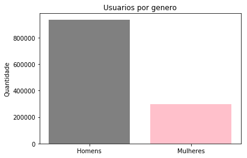

```python
# Plotando um gráfico dos generos
plt.bar(genero.index,genero, tick_label=generos, color=('Gray','Pink'))
plt.title('Usuarios por genero')
plt.ylabel('Quantidade');
```

Podemos observar uma grande diferença entre o genero dos usuarios.

```python
# Quantidade de tipos de usuarios

usuarios = conta_info('user_type')
print('Temos em nossa base:')
for registro in range(len(usuarios)):
    print(usuarios.index[registro], '-', usuarios[registro])
```

```
Temos em nossa base:
Subscriber - 1234339
Customer - 317162
Dependent - 4
```

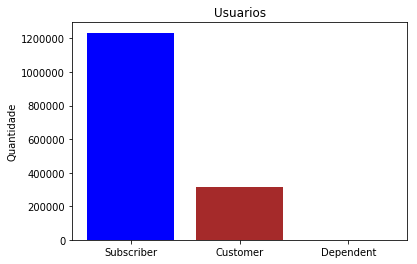

```python
# Plotando um gráfico com os tipos de usuarios

plt.bar(usuarios.index,usuarios, color=('Blue','Brown','Red'))
plt.title('Usuarios')
plt.ylabel('Quantidade');
```

Podemos observar uma grande quantidade de assinantes, um pequeno valor de usuarios e praticamente não vemos no gráfico a quantidade de dependentes devido ao seu pequeno numero (apenas 4)

```python
# Idade dos usuarios

ano = datetime.now().year #ano atual
idade = [] #criando uma ista para inserir as idades dos usuarios
df_bike['idade'] = [0 for x in df_bike['start_time']]
```

```python
idade = []
for nasc in df_bike['birth_year']:
    idade.append(ano - nasc)

df_bike['idade'] = idade
```

```python
maior_idade = int(df_bike['idade'].max())
menor_idade = int(df_bike['idade'].min())

print('\nA maior idade registrada em nossa base é de {} anos e a menor é de {} anos'
     .format(maior_idade,menor_idade))
```

```
A maior idade registrada em nossa base é de 119 anos e a menor é de 2 anos
```

Por não termos um identificador unico de cada usuario, não é possível calcular a idade média

```python
# Tempo das viagens

media_tempo = df_bike['trip_duration'].mean()
maior_tempo = df_bike['trip_duration'].max()
menor_tempo = df_bike['trip_duration'].min()
```

```python
# Adequando valores para apresentação
# Função para converter tempo
def converte_tempo(tempo):
    """
    Função que converte o tempo de segundos para minutos, horas e dias de acordo com o valor
    Utilização: funcao(tempo)
    Parametros: tempo que será convertido
    Retorna: o tempo convertido e a medida

    """

    if tempo < 60:
        medida = 'segundo(s)'
    elif tempo < 3600:
        medida = 'minuto(s)'
        tempo = tempo / 60
    elif tempo < 86400:
        medida = 'hora(s)'
        tempo = (tempo / 60) / 60
    else:
        medida = 'dia(s)'
        tempo = ((tempo / 60) / 60) / 24
    return tempo, medida
```

```python
# Testando a função
converte_tempo(media_tempo)
```

```
(15.662962650243903, 'minuto(s)')
```

```python
print('O tempo médio das viagens é de {:.1f} {}\n\nO maior tempo de viagem foi de {:.1f} {} e o menor tempo {:.1f} {}'
     .format(converte_tempo(media_tempo)[0],converte_tempo(media_tempo)[1],
             converte_tempo(maior_tempo)[0],converte_tempo(maior_tempo)[1],
             converte_tempo(menor_tempo)[0],converte_tempo(menor_tempo)[1]))
```

```
O tempo médio das viagens é de 15.7 minuto(s)

O maior tempo de viagem foi de 24.0 hora(s) e o menor tempo 1.0 minuto(s)
```

```python
print('Temos:\n {} viagens com duração acima da média\n {} viagens abaixo da media'
     .format(df_bike[df_bike['trip_duration'] > media_tempo]['trip_duration'].count(),
            df_bike[df_bike['trip_duration'] < media_tempo]['trip_duration'].count()))
```

```
Temos:
 517685 viagens com duração acima da média
 1033820 viagens abaixo da media
```

```python
print('O registro com maior duração de viagem:')
df_bike[df_bike['trip_duration'] == maior_tempo]
```

```
O registro com maior duração de viagem:
```

|  | start_time | end_time | trip_duration | start_station | end_station | user_type | gender | birth_year | idade |
| --- | --- | --- | --- | --- | --- | --- | --- | --- | --- |
| 401711 | 2017-03-26 08:07:43 | 2017-03-27 08:06:41 | 86338 | Clark St & Elm St | Halsted St & Blackhawk St (*) | Customer | NaN | NaN | NaN |

```python
print('O registro com menor duração de viagem:')
df_bike[df_bike['trip_duration'] == menor_tempo][:8]
```

```
O registro com menor duração de viagem:
```

|  | start_time | end_time | trip_duration | start_station | end_station | user_type | gender | birth_year | idade |
| --- | --- | --- | --- | --- | --- | --- | --- | --- | --- |
| 22807 | 2017-01-09 18:34:04 | 2017-01-09 18:35:04 | 60 | Wood St & Taylor St | Wood St & Taylor St | Subscriber | Male | 1981.0 | 37.0 |
| 57031 | 2017-01-19 18:08:47 | 2017-01-19 18:09:47 | 60 | Cityfront Plaza Dr & Pioneer Ct | Cityfront Plaza Dr & Pioneer Ct | Subscriber | Female | 1965.0 | 53.0 |
| 67177 | 2017-01-21 15:49:37 | 2017-01-21 15:50:37 | 60 | Western Ave & Winnebago Ave | Western Ave & Winnebago Ave | Subscriber | NaN | 1980.0 | 38.0 |
| 69240 | 2017-01-21 20:24:11 | 2017-01-21 20:25:11 | 60 | Ada St & Washington Blvd | Ada St & Washington Blvd | Subscriber | Female | 1988.0 | 30.0 |
| 77369 | 2017-01-23 18:00:16 | 2017-01-23 18:01:16 | 60 | Kingsbury St & Kinzie St | Kingsbury St & Kinzie St | Customer | NaN | NaN | NaN |
| 99820 | 2017-01-28 14:42:01 | 2017-01-28 14:43:01 | 60 | Clinton St & Washington Blvd | Canal St & Madison St | Subscriber | Male | 1983.0 | 35.0 |
| 104080 | 2017-01-30 11:58:04 | 2017-01-30 11:59:04 | 60 | Ashland Ave & 21st St | Ashland Ave & 21st St | Subscriber | Male | 1949.0 | 69.0 |
| 109372 | 2017-01-31 15:21:47 | 2017-01-31 15:22:47 | 60 | Orleans St & Merchandise Mart Plaza | Orleans St & Merchandise Mart Plaza | Subscriber | Male | 1965.0 | 53.0 |

Como podemos ver, foi considerado o menor tempo de viagem os usuarios que retiraram e bicicleta e já devolveram na estação, vamos ignorar os casos onde a estação de inicio e fim são iguais, mas manteremos o valor do menor tempo.

```python
print('Os registros com menor duração de viagem:')
df_bike[(df_bike['trip_duration'] == menor_tempo) & (df_bike['start_station'] != df_bike['end_station'])]
```

```
Os registros com menor duração de viagem:
```

|  | start_time | end_time | trip_duration | start_station | end_station | user_type | gender | birth_year | idade |
| --- | --- | --- | --- | --- | --- | --- | --- | --- | --- |
| 99820 | 2017-01-28 14:42:01 | 2017-01-28 14:43:01 | 60 | Clinton St & Washington Blvd | Canal St & Madison St | Subscriber | Male | 1983.0 | 35.0 |
| 124303 | 2017-02-03 16:53:51 | 2017-02-03 16:54:51 | 60 | Clinton St & Jackson Blvd | Canal St & Adams St | Subscriber | Male | 1964.0 | 54.0 |
| 252925 | 2017-02-23 14:38:25 | 2017-02-23 14:39:25 | 60 | Clinton St & Madison St | Clinton St & Washington Blvd | Subscriber | Male | 1949.0 | 69.0 |
| 314465 | 2017-03-07 17:53:59 | 2017-03-07 17:54:59 | 60 | Clinton St & Washington Blvd | Clinton St & Madison St | Subscriber | Male | 1982.0 | 36.0 |
| 351224 | 2017-03-16 19:08:18 | 2017-03-16 19:09:18 | 60 | Canal St & Madison St | Clinton St & Madison St | Subscriber | Male | 1953.0 | 65.0 |
| 732844 | 2017-05-04 21:12:06 | 2017-05-04 21:13:06 | 60 | Rush St & Hubbard St | State St & Kinzie St | Subscriber | Male | 1987.0 | 31.0 |
| 916422 | 2017-05-22 07:37:50 | 2017-05-22 07:38:50 | 60 | Canal St & Monroe St (*) | Canal St & Madison St | Subscriber | Male | 1990.0 | 28.0 |
| 941406 | 2017-05-24 15:19:58 | 2017-05-24 15:20:58 | 60 | Clinton St & Madison St | Clinton St & Washington Blvd | Subscriber | Female | 1991.0 | 27.0 |
| 1399109 | 2017-06-21 22:24:54 | 2017-06-21 22:25:54 | 60 | Clinton St & Washington Blvd | Clinton St & Madison St | Subscriber | Male | 1955.0 | 63.0 |

```python
# Estações
#estacao, quantidade = coluna_lista('start_station')
estacoes = conta_info('start_station')
```

```python
print('Temos um total de {} estações em nossa base'
     .format(len(estacoes)))
```

```
Temos um total de 582 estações em nossa base
```

```python
mais_reg = estacoes.max()
menos_reg = estacoes.min()
print('A estação com maior numero de registros possui {} e a menor {}'
      .format(mais_reg,menos_reg))
```

```
A estação com maior numero de registros possui 36686 e a menor 1
```

```python
print('Estações com maior numero de registro:')
pos = 0
for estacao in estacoes:
    if estacao == mais_reg:
        print('-',estacoes.index[pos])
    pos += 1
```

```
Estações com maior numero de registro:
- Streeter Dr & Grand Ave
```

```python
print('Estações com menor numero de registro:')
pos = 0
for estacao in estacoes:
    if estacao == menos_reg:
        print('-',estacoes.index[pos])
    pos += 1
```

```
Estações com menor numero de registro:
- Ashland Ave & Garfield Blvd
```

```python
# Movimentação por dia da semana

day = df_bike['start_time'].dt.day_name() #criando uma lista com os dias da semana
df_bike['day'] = day #criando uma coluna do df e inserindo os dias da semana
```

```python
df_bike.head()
```

|  | start_time | end_time | trip_duration | start_station | end_station | user_type | gender | birth_year | idade | day |
| --- | --- | --- | --- | --- | --- | --- | --- | --- | --- | --- |
| 0 | 2017-01-01 00:00:36 | 2017-01-01 00:06:32 | 356 | Canal St & Taylor St | Canal St & Monroe St (*) | Customer | NaN | NaN | NaN | Sunday |
| 1 | 2017-01-01 00:02:54 | 2017-01-01 00:08:21 | 327 | Larrabee St & Menomonee St | Sheffield Ave & Kingsbury St | Subscriber | Male | 1984.0 | 34.0 | Sunday |
| 2 | 2017-01-01 00:06:06 | 2017-01-01 00:18:31 | 745 | Orleans St & Chestnut St (NEXT Apts) | Ashland Ave & Blackhawk St | Subscriber | Male | 1985.0 | 33.0 | Sunday |
| 3 | 2017-01-01 00:07:28 | 2017-01-01 00:12:51 | 323 | Franklin St & Monroe St | Clinton St & Tilden St | Subscriber | Male | 1990.0 | 28.0 | Sunday |
| 4 | 2017-01-01 00:07:57 | 2017-01-01 00:20:53 | 776 | Broadway & Barry Ave | Sedgwick St & North Ave | Subscriber | Male | 1990.0 | 28.0 | Sunday |

```python
cont_day = conta_info('day') #contando a qtde de ocorrencias para cada dia da semana
```

```python
cont_day #conferindo o resultado
```

```
Tuesday      237586
Monday       231477
Friday       226840
Thursday     223114
Wednesday    220217
Saturday     212003
Sunday       200268
Name: day, dtype: int64
```

```python
# Reordenando os dias, seguindo o calendário

nindex = ['Sunday','Tuesday','Wednesday','Thursday','Friday','Saturday','Monday']
cont_day = cont_day.reindex(index = nindex)
```

```
(180000, 240000)
```

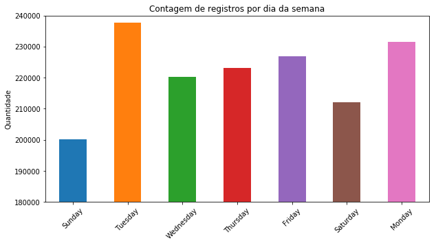

```python
# Plotando um gráfico com os registros por dia da semana

#plt.bar(cont_day.index,cont_day)
#plt.title('Contagem de registros por dia da semana')
#plt.xticks(rotation = 50);
cont_day.plot(kind='bar', title="Contagem de registros por dia da semana", rot=45, figsize=(10,5));
plt.ylabel('Quantidade')
plt.ylim(180000,240000)
```

```python
# Movimentação por mês

mes = []
mes = df_bike['start_time'].dt.month
df_bike['month'] = mes
```

```python
cont_mes = conta_info('month')
```

```python
cont_mes
```

```
6    505164
5    345988
4    268662
2    166343
3    153406
1    111942
Name: month, dtype: int64
```

```python
# Reordenando o index para corresponder a ordem dos meses
nindex = [1,2,3,4,5,6]
cont_mes = cont_mes.reindex(index = nindex)
meses = ['Janeiro','Fevereiro','Março','Abril','Maio','Junho']
cont_mes.index = meses
```

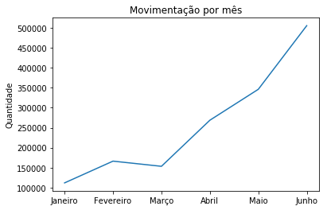

```python
# Plotando um grafico com a movimentação por mês

plt.plot(cont_mes)
plt.title('Movimentação por mês')
plt.ylabel('Quantidade');
```

A seguir iremos mesclar as estações de INICIO e FIM do trajeto, afim de termos os trajetos para analise

```python
#Criando um df apenas com as estações de partida e fim

df_trajetos = df_bike[['start_station','end_station']]
```

```python
df_trajetos.head()
```

|  | start_station | end_station |
| --- | --- | --- |
| 0 | Canal St & Taylor St | Canal St & Monroe St (*) |
| 1 | Larrabee St & Menomonee St | Sheffield Ave & Kingsbury St |
| 2 | Orleans St & Chestnut St (NEXT Apts) | Ashland Ave & Blackhawk St |
| 3 | Franklin St & Monroe St | Clinton St & Tilden St |
| 4 | Broadway & Barry Ave | Sedgwick St & North Ave |

```python
# Mesclando as estações e inserindo em uma lista
trajetos = []
pos = 0
for registro in range(df_trajetos.shape[0]):
    t1 = df_trajetos.loc[pos, 'start_station'] + ' , ' + df_trajetos.loc[pos, 'end_station']
    trajetos.append(t1)
    pos += 1
```

```python
trajetos[:10]
```

```
['Canal St & Taylor St , Canal St & Monroe St (*)',
 'Larrabee St & Menomonee St , Sheffield Ave & Kingsbury St',
 'Orleans St & Chestnut St (NEXT Apts) , Ashland Ave & Blackhawk St',
 'Franklin St & Monroe St , Clinton St & Tilden St',
 'Broadway & Barry Ave , Sedgwick St & North Ave',
 'State St & Kinzie St , Wells St & Polk St',
 'Wabash Ave & Wacker Pl , Clinton St & Tilden St',
 'Daley Center Plaza , Canal St & Monroe St (*)',
 'Daley Center Plaza , Canal St & Monroe St (*)',
 'Dayton St & North Ave , Ogden Ave & Chicago Ave']
```

```python
df_trajetos['trajeto'] = trajetos
```

```python
df_trajetos.head()
```

|  | start_station | end_station | trajeto |
| --- | --- | --- | --- |
| 0 | Canal St & Taylor St | Canal St & Monroe St (*) | Canal St & Taylor St , Canal St & Monroe St (*) |
| 1 | Larrabee St & Menomonee St | Sheffield Ave & Kingsbury St | Larrabee St & Menomonee St , Sheffield Ave & K... |
| 2 | Orleans St & Chestnut St (NEXT Apts) | Ashland Ave & Blackhawk St | Orleans St & Chestnut St (NEXT Apts) , Ashland... |
| 3 | Franklin St & Monroe St | Clinton St & Tilden St | Franklin St & Monroe St , Clinton St & Tilden St |
| 4 | Broadway & Barry Ave | Sedgwick St & North Ave | Broadway & Barry Ave , Sedgwick St & North Ave |

```python
df_trajetos.tail()
```

|  | start_station | end_station | trajeto |
| --- | --- | --- | --- |
| 1551500 | Damen Ave & Division St | Halsted St & Blackhawk St (*) | Damen Ave & Division St , Halsted St & Blackha... |
| 1551501 | Canal St & Adams St | LaSalle St & Adams St | Canal St & Adams St , LaSalle St & Adams St |
| 1551502 | Sheffield Ave & Webster Ave | Sheffield Ave & Webster Ave | Sheffield Ave & Webster Ave , Sheffield Ave & ... |
| 1551503 | Clark St & Grace St | Clark St & Montrose Ave | Clark St & Grace St , Clark St & Montrose Ave |
| 1551504 | Desplaines St & Jackson Blvd | Desplaines St & Kinzie St | Desplaines St & Jackson Blvd , Desplaines St &... |

```python
# Criando um df e armazendo os valores
cont_trajetos = pd.DataFrame()
cont_trajetos['trajeto'] = df_trajetos['trajeto'].value_counts().index
cont_trajetos['qtde'] = df_trajetos['trajeto'].value_counts().values
```

```python
cont_trajetos.head()
```

|  | trajeto | qtde |
| --- | --- | --- |
| 0 | Lake Shore Dr & Monroe St , Streeter Dr & Gran... | 4647 |
| 1 | Streeter Dr & Grand Ave , Streeter Dr & Grand Ave | 3853 |
| 2 | Streeter Dr & Grand Ave , Theater on the Lake | 2933 |
| 3 | Streeter Dr & Grand Ave , Lake Shore Dr & Nort... | 2900 |
| 4 | Streeter Dr & Grand Ave , Lake Shore Dr & Monr... | 2825 |

```python
cont_trajetos.tail()
```

|  | trajeto | qtde |
| --- | --- | --- |
| 75408 | Dayton St & North Ave , Kedzie Ave & Leland Ave | 1 |
| 75409 | Morgan St & Polk St , Sedgwick St & Webster Ave | 1 |
| 75410 | Stony Island Ave & 71st St , Stony Island Ave ... | 1 |
| 75411 | Morgan St & 18th St , Calumet Ave & 35th St | 1 |
| 75412 | Sedgwick St & North Ave , Ashland Ave & Harris... | 1 |

```python
print('Os trajetos com maior numero de ocorrencias são')
cont_trajetos[cont_trajetos['qtde'] == cont_trajetos['qtde'].max()]
```

```
Os trajetos com maior numero de ocorrencias são
```

|  | trajeto | qtde |
| --- | --- | --- |
| 0 | Lake Shore Dr & Monroe St , Streeter Dr & Gran... | 4647 |

```python
print('A quantidade de trajetos que possuem o menor valor ({}) é de {} trajeto(s)'
      .format(cont_trajetos['qtde'].min(),cont_trajetos[cont_trajetos['qtde'] == cont_trajetos['qtde'].min()]['trajeto'].count()))
```

```
A quantidade de trajetos que possuem o menor valor (1) é de 16612 trajeto(s)
```

```python
# Calculo de porcentagens para conclusão
# Usuarios
total = len(df_bike)
perc_usuarios = (usuarios * 100) / total
perc_genero = (genero * 100) / total
```

### Conclusão

```python
print('Do nosso total de {} registros de viagens, temos {:.1f}% de assinantes, {:.1f}% de usuarios'
      .format(total, perc_usuarios['Subscriber'],perc_usuarios['Customer']))
```

```
Do nosso total de 1551505 registros de viagens, temos 79.6% de assinantes, 20.4% de usuarios
```

```python
print('A grande maioria dos usuarios são homens, representando {:.1f}% e {:.1f}% são de mulheres'
     .format(perc_genero['Homens'],perc_genero['Mulheres']))
```

```
A grande maioria dos usuarios são homens, representando 60.3% e 19.3% são de mulheres
```

```python
print('O dia de maior movimento é {} com {} registros\nO dia de menor movimento é {} com {} registros'
     .format(cont_day.idxmax(),cont_day.max(),cont_day.idxmin(),cont_day.min()))
```

```
O dia de maior movimento é Tuesday com 237586 registros
O dia de menor movimento é Sunday com 200268 registros
```

```python
print('O dia de maior movimento é {} com {} registros\nO dia de menor movimento é {} com {} registros'
     .format(cont_mes.idxmax(),cont_mes.max(),cont_mes.idxmin(),cont_mes.min()))
```

```
O dia de maior movimento é Junho com 505164 registros
O dia de menor movimento é Janeiro com 111942 registros
```

```python
print('O trajeto mais utilizado é:')
cont_trajetos[cont_trajetos['qtde'] == cont_trajetos['qtde'].max()]['trajeto']
```

```
O trajeto mais utilizado é:
```

```
0    Lake Shore Dr & Monroe St , Streeter Dr & Gran...
Name: trajeto, dtype: object
```

```python
print('E temos {} trajetos com a menor quantidade registrada que é de {} registro(s)'
      .format(cont_trajetos[cont_trajetos['qtde'] == cont_trajetos['qtde'].min()]['trajeto'].count(),cont_trajetos['qtde'].min()))
```

```
E temos 16612 trajetos com a menor quantidade registrada que é de 1 registro(s)
```

### Limitadores

Durante nossa analise dos dados nos deparamos com colunas que precisam ter seus tipos ajustados para dar-mos sequencia nos trabalhos, sendo elas **start_time** e **end_time** , alêm de colunas com dados ausentes **gender**, **birth_year**.

**Tipagem:**

```
start_time e end_time: tiveram seus tipos alterados para datetime, o que nos permitiu identicair dia da semana e mês
```

**Dados ausentes:**

[output not shown]

*Devido a ausência de uma coluna que identifica-se os usuarios, não foi possui verificar os maiores e menores utilizadores, bem como dia de uso, etc*

Fabiano Lima - 04/12/2018